```python
import matplotlib.pyplot as plt
import pandas as pd
%matplotlib inline
import numpy as np
import seaborn as sns

from sklearn.model_selection import train_test_split
from sklearn.preprocessing import StandardScaler

from sklearn.linear_model import LinearRegression
from sklearn.metrics import mean_squared_error, r2_score, explained_variance_score
```

# The goal of this homework is to take census data and predict whether an individual would have an income that exceeds $50k/yr. This is a binary classification problem.

# 1. Data Processing

## a) Import the data from the website directly: https://archive.ics.uci.edu/ml/machine-learning-databases/adult/adult.dataLinks to an external site.

```python
adult_df = pd.read_csv('https://archive.ics.uci.edu/ml/machine-learning-databases/adult/adult.data', header = None, skipinitialspace=True)
adult_df.head()
```

|  | 0 | 1 | 2 | 3 | 4 | 5 | 6 | 7 | 8 | 9 | 10 | 11 | 12 | 13 | 14 |
| --- | --- | --- | --- | --- | --- | --- | --- | --- | --- | --- | --- | --- | --- | --- | --- |
| 0 | 39 | State-gov | 77516 | Bachelors | 13 | Never-married | Adm-clerical | Not-in-family | White | Male | 2174 | 0 | 40 | United-States | <=50K |
| 1 | 50 | Self-emp-not-inc | 83311 | Bachelors | 13 | Married-civ-spouse | Exec-managerial | Husband | White | Male | 0 | 0 | 13 | United-States | <=50K |
| 2 | 38 | Private | 215646 | HS-grad | 9 | Divorced | Handlers-cleaners | Not-in-family | White | Male | 0 | 0 | 40 | United-States | <=50K |
| 3 | 53 | Private | 234721 | 11th | 7 | Married-civ-spouse | Handlers-cleaners | Husband | Black | Male | 0 | 0 | 40 | United-States | <=50K |
| 4 | 28 | Private | 338409 | Bachelors | 13 | Married-civ-spouse | Prof-specialty | Wife | Black | Female | 0 | 0 | 40 | Cuba | <=50K |

## b) Add column names

```python
list_of_columns = ["age", "workclass", "fnlwgt", "education", "education-num", "marital-status", "occupation", "relationship", "race", "sex", "capital-gain", "capital-loss", "hours-per-week", "native-country", "salary"]
adult_df.columns = list_of_columns
adult_df.head()
```

|  | age | workclass | fnlwgt | education | education-num | marital-status | occupation | relationship | race | sex | capital-gain | capital-loss | hours-per-week | native-country | salary |
| --- | --- | --- | --- | --- | --- | --- | --- | --- | --- | --- | --- | --- | --- | --- | --- |
| 0 | 39 | State-gov | 77516 | Bachelors | 13 | Never-married | Adm-clerical | Not-in-family | White | Male | 2174 | 0 | 40 | United-States | <=50K |
| 1 | 50 | Self-emp-not-inc | 83311 | Bachelors | 13 | Married-civ-spouse | Exec-managerial | Husband | White | Male | 0 | 0 | 13 | United-States | <=50K |
| 2 | 38 | Private | 215646 | HS-grad | 9 | Divorced | Handlers-cleaners | Not-in-family | White | Male | 0 | 0 | 40 | United-States | <=50K |
| 3 | 53 | Private | 234721 | 11th | 7 | Married-civ-spouse | Handlers-cleaners | Husband | Black | Male | 0 | 0 | 40 | United-States | <=50K |
| 4 | 28 | Private | 338409 | Bachelors | 13 | Married-civ-spouse | Prof-specialty | Wife | Black | Female | 0 | 0 | 40 | Cuba | <=50K |

## c) Check your dataframe shape to verify that you have the correct # of rows and columns

```python
adult_df.shape
```

```
(32561, 15)
```

## d) Drop the 3rd column from the data (it is referred to as "fnlwgt" on UCI's website and is not necessary in this homework)

```python
adult_df.drop(columns=['fnlwgt'], inplace=True)
adult_df.head()
```

|  | age | workclass | education | education-num | marital-status | occupation | relationship | race | sex | capital-gain | capital-loss | hours-per-week | native-country | salary |
| --- | --- | --- | --- | --- | --- | --- | --- | --- | --- | --- | --- | --- | --- | --- |
| 0 | 39 | State-gov | Bachelors | 13 | Never-married | Adm-clerical | Not-in-family | White | Male | 2174 | 0 | 40 | United-States | <=50K |
| 1 | 50 | Self-emp-not-inc | Bachelors | 13 | Married-civ-spouse | Exec-managerial | Husband | White | Male | 0 | 0 | 13 | United-States | <=50K |
| 2 | 38 | Private | HS-grad | 9 | Divorced | Handlers-cleaners | Not-in-family | White | Male | 0 | 0 | 40 | United-States | <=50K |
| 3 | 53 | Private | 11th | 7 | Married-civ-spouse | Handlers-cleaners | Husband | Black | Male | 0 | 0 | 40 | United-States | <=50K |
| 4 | 28 | Private | Bachelors | 13 | Married-civ-spouse | Prof-specialty | Wife | Black | Female | 0 | 0 | 40 | Cuba | <=50K |

## e) Note: There are random values of '?' that show up in the data - this is fine! These just refer to "unknown" and can be left as is. This data has no true NA values, so no need to check.

## f) Use the .replace() method to make the following changes to the "salary" column

```python
adult_df.salary.replace(to_replace=['<=50K', '>50K'], value=[0, 1], inplace=True)
adult_df.head()
```

|  | age | workclass | education | education-num | marital-status | occupation | relationship | race | sex | capital-gain | capital-loss | hours-per-week | native-country | salary |
| --- | --- | --- | --- | --- | --- | --- | --- | --- | --- | --- | --- | --- | --- | --- |
| 0 | 39 | State-gov | Bachelors | 13 | Never-married | Adm-clerical | Not-in-family | White | Male | 2174 | 0 | 40 | United-States | 0 |
| 1 | 50 | Self-emp-not-inc | Bachelors | 13 | Married-civ-spouse | Exec-managerial | Husband | White | Male | 0 | 0 | 13 | United-States | 0 |
| 2 | 38 | Private | HS-grad | 9 | Divorced | Handlers-cleaners | Not-in-family | White | Male | 0 | 0 | 40 | United-States | 0 |
| 3 | 53 | Private | 11th | 7 | Married-civ-spouse | Handlers-cleaners | Husband | Black | Male | 0 | 0 | 40 | United-States | 0 |
| 4 | 28 | Private | Bachelors | 13 | Married-civ-spouse | Prof-specialty | Wife | Black | Female | 0 | 0 | 40 | Cuba | 0 |

## g) Create your X dataframe (just your predictors). It should include every feature except for the target variable which is "salary".

```python
X = adult_df.drop(columns=["salary"])
X.head()
```

|  | age | workclass | education | education-num | marital-status | occupation | relationship | race | sex | capital-gain | capital-loss | hours-per-week | native-country |
| --- | --- | --- | --- | --- | --- | --- | --- | --- | --- | --- | --- | --- | --- |
| 0 | 39 | State-gov | Bachelors | 13 | Never-married | Adm-clerical | Not-in-family | White | Male | 2174 | 0 | 40 | United-States |
| 1 | 50 | Self-emp-not-inc | Bachelors | 13 | Married-civ-spouse | Exec-managerial | Husband | White | Male | 0 | 0 | 13 | United-States |
| 2 | 38 | Private | HS-grad | 9 | Divorced | Handlers-cleaners | Not-in-family | White | Male | 0 | 0 | 40 | United-States |
| 3 | 53 | Private | 11th | 7 | Married-civ-spouse | Handlers-cleaners | Husband | Black | Male | 0 | 0 | 40 | United-States |
| 4 | 28 | Private | Bachelors | 13 | Married-civ-spouse | Prof-specialty | Wife | Black | Female | 0 | 0 | 40 | Cuba |

```python
X.shape
```

```
(32561, 13)
```

## h) Create your y dataframe (just your target variable). It should only be "salary".

```python
y = adult_df["salary"]
y.head()
```

```
0    0
1    0
2    0
3    0
4    0
Name: salary, dtype: int64
```

```python
y.value_counts()
```

```
salary
0    24720
1     7841
Name: count, dtype: int64
```

## i) For this homework we will try converting columns with factors to separate columns (i.e. one-hot encoding). It is not necessary for trees, but can be a very powerful tool to use. There are a variety of ways to do this, but we can use Pandas built-in method .get_dummies(). Pandas will automatically split out columns that are categorical. For now, just run across your full X dataframe.

```python
X_encoded = pd.get_dummies(X)
X_encoded.head()
```

|  | age | education-num | capital-gain | capital-loss | hours-per-week | workclass_? | workclass_Federal-gov | workclass_Local-gov | workclass_Never-worked | workclass_Private | ... | native-country_Portugal | native-country_Puerto-Rico | native-country_Scotland | native-country_South | native-country_Taiwan | native-country_Thailand | native-country_Trinadad&Tobago | native-country_United-States | native-country_Vietnam | native-country_Yugoslavia |
| --- | --- | --- | --- | --- | --- | --- | --- | --- | --- | --- | --- | --- | --- | --- | --- | --- | --- | --- | --- | --- | --- |
| 0 | 39 | 13 | 2174 | 0 | 40 | False | False | False | False | False | ... | False | False | False | False | False | False | False | True | False | False |
| 1 | 50 | 13 | 0 | 0 | 13 | False | False | False | False | False | ... | False | False | False | False | False | False | False | True | False | False |
| 2 | 38 | 9 | 0 | 0 | 40 | False | False | False | False | True | ... | False | False | False | False | False | False | False | True | False | False |
| 3 | 53 | 7 | 0 | 0 | 40 | False | False | False | False | True | ... | False | False | False | False | False | False | False | True | False | False |
| 4 | 28 | 13 | 0 | 0 | 40 | False | False | False | False | True | ... | False | False | False | False | False | False | False | False | False | False |

5 rows × 107 columns

```python
X_encoded.shape
```

```
(32561, 107)
```

## j) Split data into train / test set using an 70/30 split. Verify that you have the same number of columns in your X_train and X_test.

```python
# Split the data into training and testing sets (70/30 split)
X_train, X_test, y_train, y_test = train_test_split(X_encoded, y, test_size=0.3, random_state=42)

# Verify the number of columns in X_train and X_test
if X_train.shape[1] == X_test.shape[1]:
    print("Number of columns in X_train and X_test are the same.")
else:
    print("Number of columns in X_train and X_test are not the same.")
```

```
Number of columns in X_train and X_test are the same.
```

# Some concepts to clarify

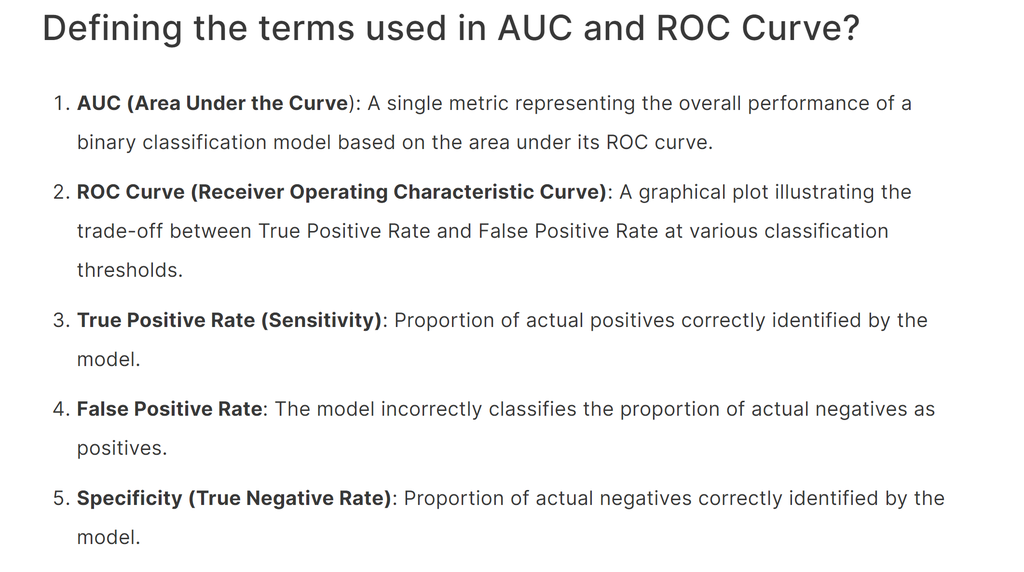

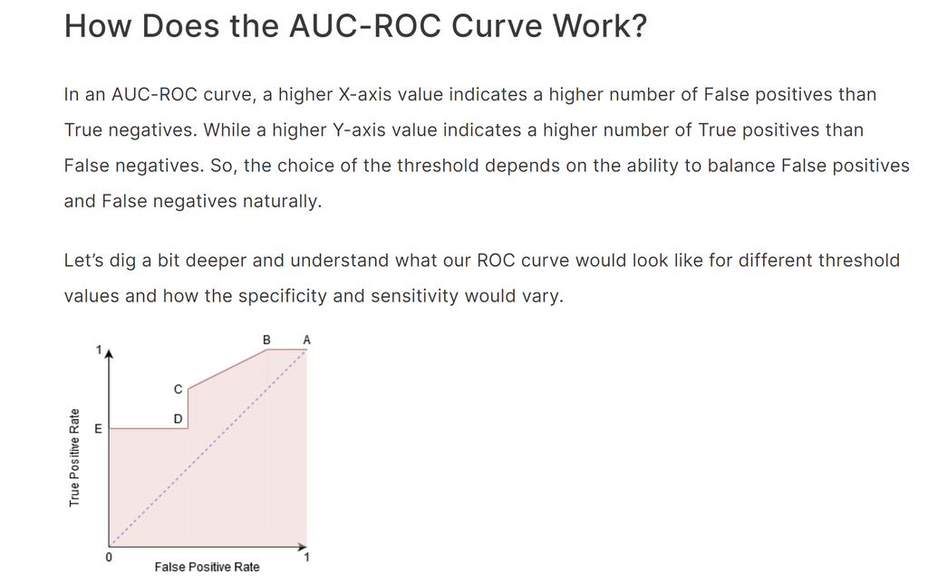

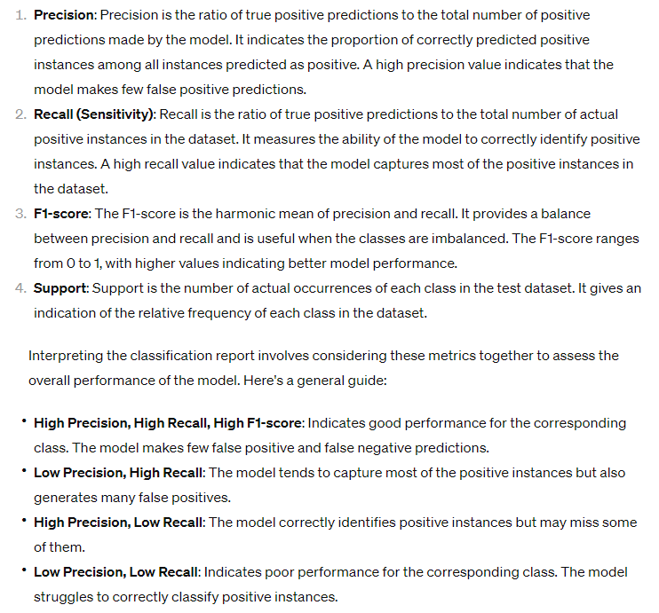

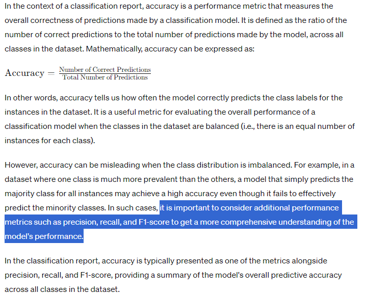

# 2. Random Forest Classifier - Base Model

## a) Fit the Random Forest model on the training data

```python
from sklearn.ensemble import RandomForestClassifier

# Create a Random Forest classifier with default parameters
rf_classifier = RandomForestClassifier(random_state=42)

# Fit the model on the training data
rf_classifier.fit(X_train, y_train)
```

```
RandomForestClassifier(random_state=42)
```

## b) Predict on the test data using the fitted model

```python
# Predict probabilities and classes for test data
y_pred_proba = rf_classifier.predict_proba(X_test)
y_pred = rf_classifier.predict(X_test)
```

```python
y_pred_proba
```

```
array([[1.        , 0.        ],
       [0.34833333, 0.65166667],
       [0.251     , 0.749     ],
       ...,
       [1.        , 0.        ],
       [0.54219048, 0.45780952],
       [0.02      , 0.98      ]])
```

```python
y_pred
```

```
array([0, 1, 1, ..., 0, 0, 1], dtype=int64)
```

## c) Calculate the confusion matrix and classification report for y_test, y_pred

```python
from sklearn.metrics import confusion_matrix, classification_report

# Calculate confusion matrix
conf_matrix = confusion_matrix(y_test, y_pred)
print("Confusion Matrix:")
print(conf_matrix)

# Calculate classification report
class_report = classification_report(y_test, y_pred)
print("\nClassification Report:")
print(class_report)
```

```
Confusion Matrix:
[[6828  627]
 [ 873 1441]]

Classification Report:
              precision    recall  f1-score   support

           0       0.89      0.92      0.90      7455
           1       0.70      0.62      0.66      2314

    accuracy                           0.85      9769
   macro avg       0.79      0.77      0.78      9769
weighted avg       0.84      0.85      0.84      9769
```

## d) Calculate the AUC score

```python
from sklearn.metrics import roc_auc_score

# Calculate AUC score
auc_score = roc_auc_score(y_test, y_pred_proba[:, 1])
print("\nAUC Score:", auc_score)
```

```
AUC Score: 0.8889081826018049
```

## e) Identify the top 5 features

```python
importances = rf_classifier.feature_importances_
indices = np.argsort(importances)[::-1]

# Print the top 5 features
print("Top 5 Features:")
for i in range(5):
    print(f"{i+1}. {X_train.columns[indices[i]]}: {importances[indices[i]]}")
```

```
Top 5 Features:
1. age: 0.2206197918208295
2. hours-per-week: 0.11370445361634884
3. capital-gain: 0.09857230928798685
4. marital-status_Married-civ-spouse: 0.07508058198623269
5. education-num: 0.06734543681554647
```

```python
importances
```

```
array([2.20619792e-01, 6.73454368e-02, 9.85723093e-02, 3.26371320e-02,
       1.13704454e-01, 2.11609110e-03, 6.27045445e-03, 6.66457222e-03,
       9.12719982e-06, 1.22437470e-02, 6.61067363e-03, 9.71760628e-03,
       5.32838113e-03, 1.20151282e-04, 1.65893365e-03, 2.28949243e-03,
       1.02152108e-03, 2.92757265e-04, 8.35497844e-04, 2.36246391e-03,
       1.43549083e-03, 3.01420132e-03, 3.46753387e-03, 1.31778130e-02,
       4.04549438e-03, 9.12516436e-03, 8.71275968e-03, 3.88965138e-05,
       4.56899561e-03, 5.85653012e-03, 7.73160319e-03, 3.95094419e-04,
       7.50805820e-02, 9.79300501e-04, 2.84849646e-02, 1.61707028e-03,
       1.74998852e-03, 1.97730439e-03, 6.32040298e-03, 7.64928444e-06,
       7.80678886e-03, 2.08468445e-02, 4.92294837e-03, 3.69980537e-03,
       4.94885544e-03, 7.09459875e-03, 1.65159183e-04, 1.71910326e-02,
       3.13229306e-03, 8.12958198e-03, 5.41330302e-03, 4.94255114e-03,
       3.80688685e-02, 1.16760150e-02, 1.53788309e-03, 8.22146296e-03,
       4.79635912e-03, 1.11897061e-02, 1.40550968e-03, 3.29801483e-03,
       5.94131521e-03, 9.44156344e-04, 7.61924201e-03, 1.02740824e-02,
       1.03635991e-02, 2.99096593e-03, 3.42776896e-04, 1.28251554e-03,
       5.73883431e-04, 2.89206551e-04, 7.92415188e-04, 1.99258088e-04,
       2.18495796e-04, 2.53527802e-04, 1.00901483e-03, 3.82817342e-04,
       1.19304306e-03, 4.39755261e-04, 1.47749795e-04, 1.96849888e-04,
       1.92358886e-07, 2.56642226e-06, 1.71659586e-04, 1.27377018e-04,
       9.05476898e-04, 3.58037229e-04, 2.74904409e-04, 7.60307587e-04,
       4.52138059e-04, 7.87810516e-04, 8.71064259e-05, 1.90844531e-03,
       1.04998890e-04, 6.49767645e-05, 9.26951953e-05, 1.12986173e-03,
       5.81136662e-04, 2.04776185e-04, 6.21454282e-04, 7.15087240e-05,
       7.42160021e-04, 4.00253552e-04, 3.12134187e-05, 1.45843841e-04,
       7.16492972e-03, 3.06032961e-04, 3.52450353e-04])
```

## f) Predict for the train data and check for overfitting

```python
# Predict on train data
y_train_pred = rf_classifier.predict(X_train)

# Calculate classification report for train data
train_class_report = classification_report(y_train, y_train_pred)
print("\nClassification Report for Train Data:")
print(train_class_report)
```

```
Classification Report for Train Data:
              precision    recall  f1-score   support

           0       0.98      0.99      0.99     17265
           1       0.97      0.95      0.96      5527

    accuracy                           0.98     22792
   macro avg       0.98      0.97      0.97     22792
weighted avg       0.98      0.98      0.98     22792
```

## Based on the Classification Report for Train Data and Test Data:

## The model performs very well on the training data (e.g., high accuracy, precision, recall, F1-score), but significantly worse on the test data (especially class 1), it suggests overfitting. Overfitting occurs when the model learns to memorize the training data patterns instead of generalizing well to new, unseen data.

# 3. AdaBoost Classifier - GridSearch

## a) Use AdaBoostClassifier with GridSearchCV

```python
from sklearn.ensemble import AdaBoostClassifier
from sklearn.model_selection import GridSearchCV

# Create AdaBoost classifier
adaboost_clf = AdaBoostClassifier(random_state=42)

# Define parameters grid
param_grid = {
    'n_estimators': [100, 200, 300, 400],
    'learning_rate': [0.2, 0.4, 0.6, 0.8, 1, 1.2]
}

# Create GridSearchCV object
# 5 cross-fold: cv=5
# scoring use "roc_auc": scoring='roc_auc'
grid_search = GridSearchCV(adaboost_clf, param_grid, cv=5, scoring='roc_auc')

# Fit GridSearchCV on training data
grid_search.fit(X_train, y_train)

# Get best estimator
best_adaboost = grid_search.best_estimator_
```

```python
best_adaboost
```

```
AdaBoostClassifier(learning_rate=1.2, n_estimators=400, random_state=42)
```

## b) Use the best estimator to predict on test data

```python
# Predict probabilities and classes for test data
y_pred_proba = best_adaboost.predict_proba(X_test)
y_pred = best_adaboost.predict(X_test)
```

```python
y_pred_proba
```

```
array([[0.50235922, 0.49764078],
       [0.49989469, 0.50010531],
       [0.49971672, 0.50028328],
       ...,
       [0.5027286 , 0.4972714 ],
       [0.49999487, 0.50000513],
       [0.49387416, 0.50612584]])
```

```python
y_pred
```

```
array([0, 1, 1, ..., 0, 1, 1], dtype=int64)
```

## c) Calculate the confusion matrix and classification report for y_test, y_pred

```python
from sklearn.metrics import confusion_matrix, classification_report

# Calculate confusion matrix
conf_matrix = confusion_matrix(y_test, y_pred)
print("Confusion Matrix:")
print(conf_matrix)

# Calculate classification report
class_report = classification_report(y_test, y_pred)
print("\nClassification Report:")
print(class_report)
```

```
Confusion Matrix:
[[7008  447]
 [ 807 1507]]

Classification Report:
              precision    recall  f1-score   support

           0       0.90      0.94      0.92      7455
           1       0.77      0.65      0.71      2314

    accuracy                           0.87      9769
   macro avg       0.83      0.80      0.81      9769
weighted avg       0.87      0.87      0.87      9769
```

## d) Calculate the AUC score

```python
from sklearn.metrics import roc_auc_score

# Calculate AUC score
auc_score = roc_auc_score(y_test, y_pred_proba[:, 1])
print("\nAUC Score:", auc_score)
```

```
AUC Score: 0.9244122180504519
```

## e) Identify the top 5 features

```python
importances = best_adaboost.feature_importances_
indices = np.argsort(importances)[::-1]

# Print the top 5 features
print("Top 5 Features:")
for i in range(5):
    print(f"{i+1}. {X_train.columns[indices[i]]}: {importances[indices[i]]}")
```

```
Top 5 Features:
1. capital-gain: 0.33
2. capital-loss: 0.29
3. age: 0.1075
4. hours-per-week: 0.0575
5. education-num: 0.01
```

## f) Predict for the train data and check for overfitting

```python
# Predict on train data
y_train_pred = best_adaboost.predict(X_train)

# Calculate classification report for train data
train_class_report = classification_report(y_train, y_train_pred)
print("\nClassification Report for Train Data:")
print(train_class_report)
```

```
Classification Report for Train Data:
              precision    recall  f1-score   support

           0       0.90      0.94      0.92     17265
           1       0.78      0.66      0.71      5527

    accuracy                           0.87     22792
   macro avg       0.84      0.80      0.82     22792
weighted avg       0.87      0.87      0.87     22792
```

## Based on the Classification Report for Train Data and Test Data:

## The model performs very well on the training data (e.g., high accuracy, precision, recall, F1-score), almost same performance on the test data. There is no overfitting for the best estimator.

# 4. Gradient Boosting Classifier - GridSearch

## a) Use GradientBoostingClassifier with GridSearchCV

```python
from sklearn.ensemble import GradientBoostingClassifier
from sklearn.model_selection import GridSearchCV

# Create GradientBoosting classifier
gb_clf = GradientBoostingClassifier(random_state=42)

# Define parameters grid
param_grid = {
    'n_estimators': [100, 200, 300, 400],
    'learning_rate': [0.1, 0.05, 0.01],  # Choose 3 learning rates of your choice
    'max_depth': [1, 2]
}

# Create GridSearchCV object
grid_search = GridSearchCV(gb_clf, param_grid, cv=5, scoring='roc_auc')

# Fit GridSearchCV on training data
grid_search.fit(X_train, y_train)

# Get best estimator
best_gb = grid_search.best_estimator_
```

## b) Use the best estimator to predict on test data

```python
# Predict probabilities and classes for test data
y_pred_proba = best_gb.predict_proba(X_test)
y_pred = best_gb.predict(X_test)
```

## c) Calculate the confusion matrix and classification report for y_test, y_pred

```python
from sklearn.metrics import confusion_matrix, classification_report

# Calculate confusion matrix
conf_matrix = confusion_matrix(y_test, y_pred)
print("Confusion Matrix:")
print(conf_matrix)

# Calculate classification report
class_report = classification_report(y_test, y_pred)
print("\nClassification Report:")
print(class_report)
```

```
Confusion Matrix:
[[7050  405]
 [ 841 1473]]

Classification Report:
              precision    recall  f1-score   support

           0       0.89      0.95      0.92      7455
           1       0.78      0.64      0.70      2314

    accuracy                           0.87      9769
   macro avg       0.84      0.79      0.81      9769
weighted avg       0.87      0.87      0.87      9769
```

## d) Calculate the AUC score

```python
from sklearn.metrics import roc_auc_score

# Calculate AUC score
auc_score = roc_auc_score(y_test, y_pred_proba[:, 1])
print("\nAUC Score:", auc_score)
```

```
AUC Score: 0.9234202970632784
```

## e) Identify the top 5 features

```python
importances = best_gb.feature_importances_
indices = np.argsort(importances)[::-1]

# Print the top 5 features
print("Top 5 Features:")
for i in range(5):
    print(f"{i+1}. {X_train.columns[indices[i]]}: {importances[indices[i]]}")
```

```
Top 5 Features:
1. marital-status_Married-civ-spouse: 0.36807583098734736
2. capital-gain: 0.22031819635667305
3. education-num: 0.1803706544233628
4. capital-loss: 0.06324309392292984
5. age: 0.05974193668791607
```

## f) Predict for the train data and check for overfitting

```python
# Predict on train data
y_train_pred = best_gb.predict(X_train)

# Calculate classification report for train data
train_class_report = classification_report(y_train, y_train_pred)
print("\nClassification Report for Train Data:")
print(train_class_report)
```

```
Classification Report for Train Data:
              precision    recall  f1-score   support

           0       0.89      0.95      0.92     17265
           1       0.80      0.64      0.71      5527

    accuracy                           0.87     22792
   macro avg       0.84      0.80      0.82     22792
weighted avg       0.87      0.87      0.87     22792
```

## Based on the Classification Report for Train Data and Test Data:

## The model performs very well on the training data (e.g., high accuracy, precision, recall, F1-score), almost same performance on the test data. There is no overfitting for the best estimator.

# 5. XGBoost - RandomizedSearchCV

```python
!pip install xgboost
```

## a) Use XGBoost with RandomizedSearchCV

```python
from xgboost import XGBClassifier
from sklearn.model_selection import RandomizedSearchCV
from scipy.stats import randint, uniform

# Create XGBoost classifier
xgb_clf = XGBClassifier(random_state=42)

# Define parameters distribution
param_dist = {
    'n_estimators': range(100, 1001, 50),
    'learning_rate': [i * 0.1 for i in range(1, 17)],
    'max_depth': [1, 2],
    'gamma': [i * 0.25 for i in range(21)]
}

# Create RandomizedSearchCV object
random_search = RandomizedSearchCV(xgb_clf, param_distributions=param_dist, n_iter=100, cv=5, scoring='roc_auc', random_state=42)

# Fit RandomizedSearchCV on training data
random_search.fit(X_train, y_train)

# Get best estimator
best_xgb = random_search.best_estimator_
```

## b) Use the best estimator to predict on test data

```python
# Predict probabilities and classes for test data
y_pred_proba = best_xgb.predict_proba(X_test)
y_pred = best_xgb.predict(X_test)
```

## c) Calculate the confusion matrix and classification report for y_test, y_pred

```python
from sklearn.metrics import confusion_matrix, classification_report

# Calculate confusion matrix
conf_matrix = confusion_matrix(y_test, y_pred)
print("Confusion Matrix:")
print(conf_matrix)

# Calculate classification report
class_report = classification_report(y_test, y_pred)
print("\nClassification Report:")
print(class_report)
```

```
Confusion Matrix:
[[7024  431]
 [ 823 1491]]

Classification Report:
              precision    recall  f1-score   support

           0       0.90      0.94      0.92      7455
           1       0.78      0.64      0.70      2314

    accuracy                           0.87      9769
   macro avg       0.84      0.79      0.81      9769
weighted avg       0.87      0.87      0.87      9769
```

## d) Calculate the AUC score

```python
from sklearn.metrics import roc_auc_score

# Calculate AUC score
auc_score = roc_auc_score(y_test, y_pred_proba[:, 1])
print("\nAUC Score:", auc_score)
```

```
AUC Score: 0.925862782572705
```

## e) Identify the top 5 features

```python
importances = best_xgb.feature_importances_
indices = np.argsort(importances)[::-1]

# Print the top 5 features
print("Top 5 Features:")
for i in range(5):
    print(f"{i+1}. {X_train.columns[indices[i]]}: {importances[indices[i]]}")
```

```
Top 5 Features:
1. marital-status_Married-civ-spouse: 0.7841019630432129
2. education-num: 0.07684514671564102
3. education_Bachelors: 0.013423610478639603
4. occupation_Exec-managerial: 0.012662194669246674
5. education_Masters: 0.012504271231591702
```

## f) Predict for the train data and check for overfitting

```python
# Predict on train data
y_train_pred = best_xgb.predict(X_train)

# Calculate classification report for train data
train_class_report = classification_report(y_train, y_train_pred)
print("\nClassification Report for Train Data:")
print(train_class_report)
```

```
Classification Report for Train Data:
              precision    recall  f1-score   support

           0       0.90      0.94      0.92     17265
           1       0.79      0.66      0.72      5527

    accuracy                           0.87     22792
   macro avg       0.84      0.80      0.82     22792
weighted avg       0.87      0.87      0.87     22792
```

## Based on the Classification Report for Train Data and Test Data:

## The model performs well on the training data (e.g., high accuracy, precision, recall, F1-score), similar performance on the test data. There is no overfitting for the best estimator.

# 6. Moving into Conceptual Problems

## a) The lecture notes describe the Gini Index (Gini impurity) which is the default criterion used for splitting in sklearn's version of RandomForestClassifier. How does the Gini Index work? (i.e. How is it used to build a top-performing model?).

The Gini index, also known as Gini impurity, is a measure of impurity or randomness in a set of data. In the context of decision trees and random forests, **the Gini index is used as a criterion to evaluate the quality of a split at each node** during the tree-building process.

Here's how the Gini index works and how it is used to build a top-performing model:

Initial Step:

At each node of the decision tree, the dataset is partitioned into subsets based on the values of a particular feature. The Gini index is **calculated for each feature to determine the impurity of the subsets.**

Calculating Gini Index:

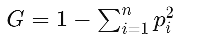

where n is the number of classes and pi is the probability of class i occurring in the subset.

Splitting Decision:

The feature **with the lowest Gini index after splitting is chosen as the splitting criterion**. **Lower Gini index values indicate less impurity**, meaning that the split separates the classes more cleanly.

Building the Tree:

The decision tree recursively applies this process to each subset created by the split until a stopping criterion is met (e.g., maximum depth of the tree, minimum number of samples in a leaf node).

Random Forests:

In the case of random forests, multiple decision trees are trained on random subsets of the training data and with random subsets of features. Each tree is trained using the Gini index to determine the best splits, and the final prediction is made by aggregating the predictions of all trees (e.g., through majority voting for classification tasks).

By using the Gini index as the criterion for splitting, decision trees and random forests aim to minimize impurity and maximize homogeneity within each subset, leading to the creation of a top-performing model that effectively separates different classes in the dataset.

## b) Describe how Random Forest is different from bagging & why this difference can yield improved results.

Base Learner Selection:

Bagging: In bagging, each base learner (often decision trees) is trained independently on a random subset of the training data, sampled with replacement (bootstrap sampling). The predictions of all base learners are then aggregated through averaging (for regression) or voting (for classification).

Random Forest: Random Forest is an extension of bagging where each base learner is a decision tree, similar to bagging. However, in addition to using bootstrap sampling, Random Forest introduces an additional randomness factor by **randomly selecting a subset of features at each node when building the decision trees**. This random feature selection helps **decorrelate the trees and reduce overfitting.**

Feature Randomness:

Bagging: Bagging typically uses all features available in the dataset when training each base learner. While bootstrap sampling introduces randomness in the data, **the features used for splitting nodes in the decision trees remain the same across all trees**.

Random Forest: Random Forest introduces feature randomness by **randomly selecting a subset of features at each node to consider for splitting**. This means that each decision tree in the Random Forest is trained on a different subset of features, leading to diverse trees that make uncorrelated decisions.

Bias-Variance Tradeoff:

Bagging: Bagging helps reduce the variance of the model by averaging predictions from multiple base learners, thereby reducing overfitting. However, it may not reduce bias significantly if the **base learners are highly correlated**.

Random Forest: By introducing feature randomness, Random Forest **decorrelates the trees and reduces the likelihood of overfitting**. This can lead to **further reduction in variance** compared to bagging, while also potentially reducing bias due to the diversity of the trees.

Overall, the key difference between Random Forest and bagging lies in the introduction of feature randomness in Random Forest. This additional randomness helps decorrelate the trees and reduces overfitting, which can lead to improved generalization performance and better results on unseen data compared to traditional bagging.

## c) Describe the importance of the max_depth parameter in Random Forest. Do not just provide a definition, rather think through how bias-variance tradeoff might be impacted by the max_depth parameter.

The max_depth parameter in Random Forest determines the maximum depth allowed for each decision tree in the ensemble. It plays a crucial role in controlling the bias-variance tradeoff and influencing the performance of the Random Forest model.

Impact on Bias:

Low max_depth: When the max_depth is low, the decision trees in the Random Forest are shallow, meaning they have fewer splits and are less complex. This can lead to high bias, as the trees may not capture all the underlying patterns in the data. High max_depth: Conversely, setting a high max_depth allows the trees to grow deeper and capture more complex patterns in the data. This can potentially reduce bias, as the trees are more capable of fitting the training data closely.

Impact on Variance:

Low max_depth: Shallow trees are less prone to overfitting and have lower variance, as they generalize better to unseen data. However, excessively shallow trees may underfit the data and fail to capture important patterns, leading to high bias. High max_depth: Deeper trees have higher variance, as they can capture more intricate details in the training data and may fit the noise in the data. This can lead to overfitting, where the model performs well on the training data but poorly on unseen data due to capturing noise.

Optimal max_depth:

The optimal max_depth value strikes a balance between bias and variance to achieve the best generalization performance on unseen data. It is often determined through hyperparameter tuning techniques such as cross-validation, where different values of max_depth are evaluated based on metrics like accuracy, precision, recall, or AUC score.

Bias-Variance Tradeoff:

Adjusting the max_depth parameter in Random Forest impacts the bias-variance tradeoff. A low max_depth reduces variance by limiting the complexity of individual trees but may increase bias. Conversely, a high max_depth increases variance by allowing trees to capture more complex patterns but may lead to overfitting and higher bias. Finding the right max_depth value involves balancing bias and variance to achieve optimal model performance and generalization to unseen data.

In summary, the max_depth parameter in Random Forest is critical for controlling the tradeoff between bias and variance. Understanding its impact allows for the construction of Random Forest models that generalize well to unseen data while avoiding overfitting.

## d) What does the alpha parameter represent in AdaBoost? Please refer to chapter 7 of the Hands-On ML book if you are struggling.

In AdaBoost, the alpha parameter **represents the weight assigned to each weak learner (base estimator)** when making predictions and during the updating of sample weights. It is calculated based on the performance of the weak learner on the training data.

Specifically, the alpha parameter is used to calculate the contribution of each weak learner to the final ensemble prediction. **Weak learners that perform well on the training data are assigned higher weights (alpha values)**, indicating that their predictions have a **greater influence on the final prediction of the AdaBoost classifier**.

The formula for calculating the alpha parameter in AdaBoost is as follows:

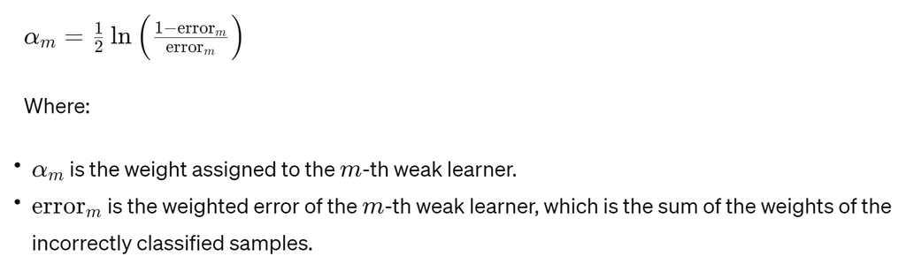

The alpha parameter is then used to update the sample weights, giving more weight to misclassified samples so that subsequent weak learners focus more on these difficult-to-classify instances.

By adjusting the alpha parameter, AdaBoost effectively emphasizes the contributions of the most accurate weak learners while downweighting those that perform poorly, leading to a more robust and accurate ensemble model.

## e) In AdaBoost explain how the final predicted class is determined. Be sure to reference the alpha term in your explanation.

In AdaBoost, the final predicted class is determined through a weighted combination of the predictions made by each weak learner (base estimator) in the ensemble. The alpha parameter, which represents the weight assigned to each weak learner based on its performance, plays a crucial role in this process.

Here's how the final predicted class is determined in AdaBoost:

Weighted Voting:

Each weak learner in the AdaBoost ensemble makes a prediction on the input data. The contribution of each weak learner to the final prediction is weighted by its alpha value. Weak learners with higher alpha values have a greater influence on the final prediction.

Weighted Sum:

The weighted predictions of all weak learners are summed together to obtain a weighted sum **for each class label**. The **class label with the highest weighted sum** is chosen as the final predicted class.

[figure not shown]

By weighting the predictions of each weak learner based on its alpha value, AdaBoost gives more weight to the predictions of more accurate weak learners while downweighting those of less accurate ones. This allows AdaBoost to leverage the strengths of individual weak learners and combine them into a strong ensemble model that often outperforms any individual weak learner.

## f) In Gradient Boosting, what is the role of the max_depth parameter? Why is it important to tune on this parameter?

In Gradient Boosting, the max_depth parameter controls the maximum depth of the individual decision trees (base learners) in the ensemble. It determines the complexity of each tree and plays a crucial role in the performance and behavior of the Gradient Boosting model. Here's why the max_depth parameter is important and its role in Gradient Boosting:

Control Overfitting:

Setting a lower value for max_depth results in shallow trees with fewer splits, which are less likely to overfit the training data. Shallow trees are simpler and generalize better to unseen data. Conversely, higher values of max_depth allow the trees to grow deeper and capture more complex patterns in the training data. While this may improve the model's performance on the training data, it also increases the risk of overfitting, where the model memorizes noise in the training data and performs poorly on unseen data.

Impact on Training Time:

Deeper trees with higher values of max_depth tend to have more nodes and require more computation during training. This can significantly increase the training time, especially for large datasets or when using complex models. Limiting the max_depth can help reduce the computational cost of training the Gradient Boosting model, making it more efficient, particularly in real-time or resource-constrained environments.

Bias-Variance Tradeoff:

Tuning the max_depth parameter involves balancing the bias-variance tradeoff. Shallow trees (low max_depth) may have higher bias but lower variance, while deeper trees (high max_depth) may have lower bias but higher variance. By selecting an optimal value for max_depth, you can find a balance between bias and variance that maximizes the model's predictive performance on unseen data.

Preventing Overfitting:

Proper tuning of the max_depth parameter is essential to prevent overfitting in Gradient Boosting models. Overfitting occurs when the model captures noise and spurious patterns in the training data, leading to poor generalization performance. Tuning max_depth helps control the complexity of the individual trees and the overall complexity of the ensemble model, thereby mitigating the risk of overfitting.

In summary, the max_depth parameter in Gradient Boosting plays a critical role in controlling model complexity, preventing overfitting, and optimizing the bias-variance tradeoff. It is essential to tune this parameter carefully to achieve the best possible performance and generalization of the Gradient Boosting model on unseen data.

## g) In Part (e) of Steps 2-5 you determined the top 5 predictors across each model. Do any predictors show up in the top 5 predictors for all 4 models? If so, comment on if this predictor makes sense given what you are attempting to predict. (Note: If you don't have any predictors showing up across all 3 predictors, explain one that shows up in 2 of them).

Random Forest Classifier

Top 5 Features:

1. age: 0.2206197918208295
2. hours-per-week: 0.11370445361634884
3. capital-gain: 0.09857230928798685
4. marital-status_Married-civ-spouse: 0.07508058198623269
5. education-num: 0.06734543681554647

AdaBoost Classifier

Top 5 Features:

1. capital-gain: 0.33
2. capital-loss: 0.29
3. age: 0.1075
4. hours-per-week: 0.0575
5. education-nu: 0.01

Gradient Boosting Classifier

XGBoost

"education-num" shows up in the top 5 predictors for all 4 models

This predictor makes sense given we are trying to predict salary. Closely related.

## h) From the models run in steps 2-5, which performs the best based on the Classification Report? Support your reasoning with evidence from your test data and be sure to share the optimal hyperparameters found from your grid search.

Based on confusion matrix and classification report for y_test, y_pred, AdaBoost Classifier performs the best.

the optimal hyperparameters found from grid search

AdaBoostClassifier(learning_rate=1.2, n_estimators=400, random_state=42)

## i) For your best performing model, plot out a ROC curve using your test data. Feel free to use sklearn, matplotlib or any other method in python. Describe what the x-axis & y-axis of the ROC curve tell us about a classifier.

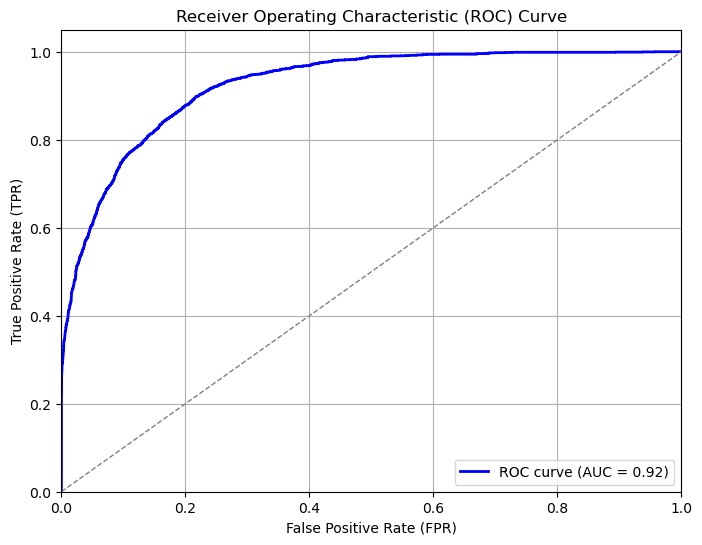

```python
import matplotlib.pyplot as plt
from sklearn.metrics import roc_curve, roc_auc_score

# Get predicted probabilities for the positive class (class 1)
y_pred_proba = best_adaboost.predict_proba(X_test)[:, 1]

# Compute ROC curve and AUC score
fpr, tpr, thresholds = roc_curve(y_test, y_pred_proba)
auc_score = roc_auc_score(y_test, y_pred_proba)

# Plot ROC curve
plt.figure(figsize=(8, 6))
plt.plot(fpr, tpr, color='blue', lw=2, label='ROC curve (AUC = %0.2f)' % auc_score)
plt.plot([0, 1], [0, 1], color='gray', linestyle='--', lw=1)
plt.xlim([0.0, 1.0])
plt.ylim([0.0, 1.05])
plt.xlabel('False Positive Rate (FPR)')
plt.ylabel('True Positive Rate (TPR)')
plt.title('Receiver Operating Characteristic (ROC) Curve')
plt.legend(loc='lower right')
plt.grid(True)
plt.show()
```

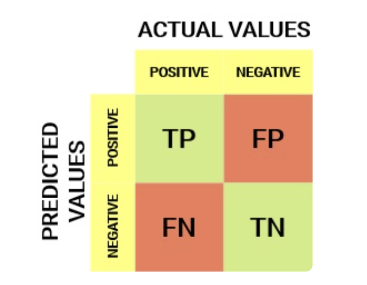

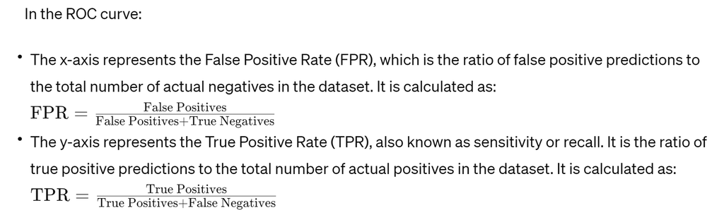

The ROC curve visually represents the trade-off between the True Positive Rate and the False Positive Rate across different threshold values. A classifier with a higher area under the ROC curve (AUC) is considered to have better performance in distinguishing between the positive and negative classes. The diagonal line (dashed gray line) represents the ROC curve of a random classifier, and points above this line indicate better-than-random performance.